# Unit 5 — Comparing more than two groups

Unit 4 asked whether **two** groups differ. Here there are three or more, and the question is the same — but asking it once for every pair of groups stops working, and the first thing this unit shows is why.

| Outcome | Groups | Omnibus test | Follow-up | Effect size |
| --- | --- | --- | --- | --- |
| Continuous, roughly normal within groups | Three or more, independent | Welch's one-way ANOVA | Games–Howell | ω² (with η² beside it) |
| Ordinal, or clearly not normal | Three or more, independent | Kruskal–Wallis | Dunn's test, with a stated correction | η²(*H*) |

The six steps from Unit 4 carry over unchanged, with one addition. Step 4 now has two halves: an **omnibus** test asks whether *any* group differs, and a **post-hoc** comparison asks *which*.

1. **State** the hypothesis pair.
2. **Inspect** the variables.
3. **Check** the assumptions and decide which test to use.
4. **Run** the omnibus test — then, if it finds something, the post-hoc comparisons.
5. **Report** the result with an effect size.
6. **Conclude** about the hypothesis.

```python
import math9102 as m9
import numpy as np
import pandas as pd
import pingouin as pg
from scipy import stats

m9.use_house_style()
```

## Why not just run lots of *t*-tests?

Three groups make three pairs. Six groups make fifteen. Run a *t*-test on each pair at the five per cent level and every one of them has its own one-in-twenty chance of a false positive. The chance that *at least one* of them is a false positive — the **familywise error rate** — grows with every pair you add:

```python
for k in range(3, 8):
    pairs = k * (k - 1) // 2
    print(f"{k} groups, {pairs:2d} pairs: P(at least one false positive) ~ {1 - 0.95 ** pairs:.2f}")
```

```
3 groups,  3 pairs: P(at least one false positive) ~ 0.14
4 groups,  6 pairs: P(at least one false positive) ~ 0.26
5 groups, 10 pairs: P(at least one false positive) ~ 0.40
6 groups, 15 pairs: P(at least one false positive) ~ 0.54
7 groups, 21 pairs: P(at least one false positive) ~ 0.66
```

The figure is approximate, because tests that share a group are not independent, but the direction is not in doubt. Somewhere around six groups, a batch of *t*-tests is more likely than not to report a difference that is not there.

ANOVA avoids this by asking **one** question of all the groups at once. That is what "omnibus" means.

## Part 1 — Optimism across three age groups

The wellbeing survey from Unit 4: four hundred and thirty-nine respondents from Melbourne, with validated scales for optimism, stress, self-esteem and more.

```python
survey = m9.load_survey()
survey.shape
```

```
(439, 134)
```

### Step 1: State the hypothesis

> **H₀:** Mean optimism is the same in all three age groups.

> **H₁:** Mean optimism differs in at least one age group.

Read H₁ carefully. It does not say every group differs from every other. One group differing from the rest is enough to make H₀ false, and that is all a significant omnibus test can tell you.

The outcome is `toptim`, the total score on the Life Orientation Test. The grouping variable is `agegp3`, with three bands.

### Step 2: Inspect the variables

```python
# Step 2. The grouping variable, then the outcome within each group.
# Sorting is not an order: say what the order is once, and reuse it.
ages = ["18 - 29", "30 - 44", "45+"]
m9.frequency(survey, "agegp3")
m9.describe_by(survey, "toptim", "agegp3")
```

| agegp3 | n | missing | mean | sd | se | median | iqr | min | max | skew | kurtosis |
| --- | --- | --- | --- | --- | --- | --- | --- | --- | --- | --- | --- |
| 18 - 29 | 147.0 | 2.0 | 21.361 | 4.551 | 0.375 | 22.0 | 5.0 | 7.0 | 30.0 | -0.611 | 0.595 |
| 30 - 44 | 153.0 | 0.0 | 22.105 | 4.147 | 0.335 | 22.0 | 6.0 | 10.0 | 30.0 | -0.400 | 0.059 |
| 45+ | 135.0 | 2.0 | 22.956 | 4.485 | 0.386 | 23.0 | 7.0 | 8.0 | 30.0 | -0.489 | -0.166 |

These three bands happen to sort into age order. That is luck, not a rule — Part 2 has a dataset where alphabetical order puts the youngest group last. Writing the order out once, as `ages`, means every table, plot and sentence below uses the same one.

```python
# What a complete-case analysis costs, on the model variables only.
missing = m9.missingness(survey, ["toptim", "agegp3"])
print(missing.attrs["summary"])
missing
```

```
Listwise deletion across these 2 column(s) keeps 435 of 439 rows (loses 4, 0.9%).
```

|  | column | missing | percent |
| --- | --- | --- | --- |
| 0 | toptim | 4 | 0.91 |
| 1 | agegp3 | 0 | 0.00 |

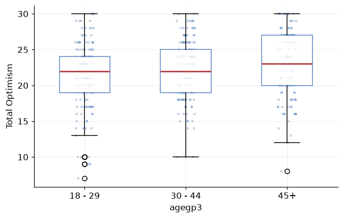

```python
m9.grouped_box(survey, "toptim", "agegp3", ylabel="Total Optimism", order=ages);
```

Read the plot before any test. The group means edge upward with age, but the boxes overlap almost entirely: whatever the test says, expect a small effect.

### Step 3: Check the assumptions

ANOVA assumes the outcome is roughly normal **within each group**, as the *t*-test did. Check each group, not the pooled outcome.

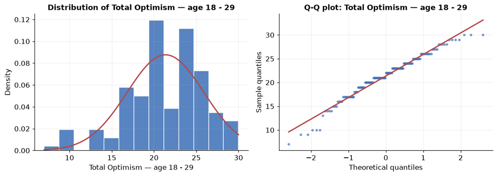

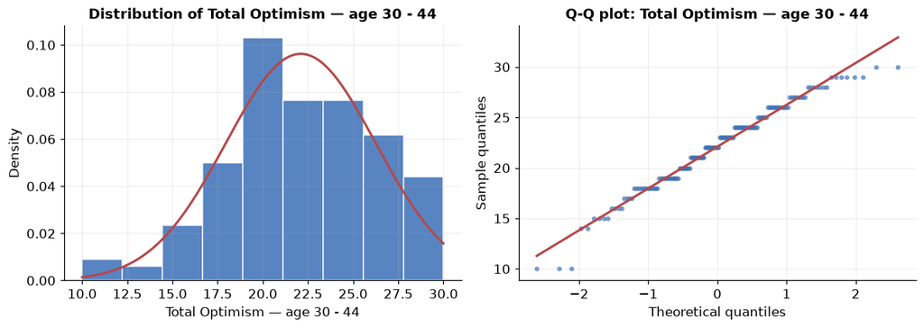

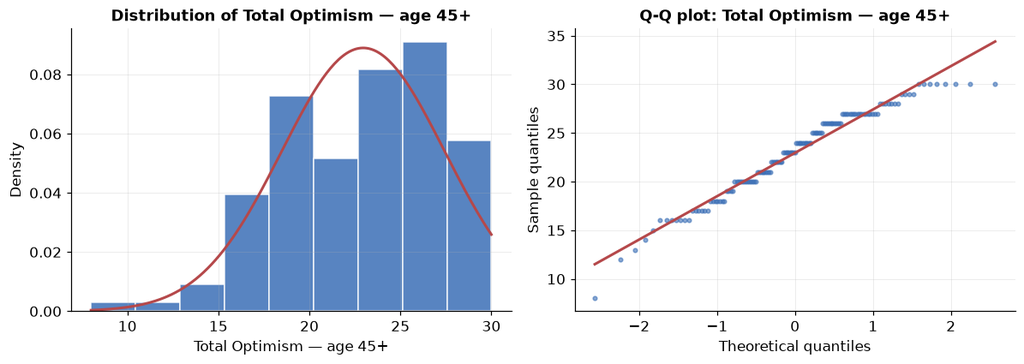

```python
for age in ages:
    m9.normality_panel(survey.loc[survey.agegp3 == age, "toptim"],
                       label=f"Total Optimism — age {age}")
```

```python
for age in ages:
    display(m9.report_normality(survey[survey.agegp3 == age], "toptim",
                                f"Total Optimism (age {age})"))
```

Total Optimism (age 18 - 29) was assessed for normality using the histogram and Q-Q plot above, supported by shape statistics (*N* = 147, *M* = 21.36, *SD* = 4.55). Skewness was -0.61 (standardised -3.05) and kurtosis 0.59 (standardised 1.50). The sample is small enough that these ratios have limited power, so the visual evidence carries most of the weight. 0.0% of standardised scores fell beyond ±3.29, against about 0.1% expected under normality.

Total Optimism (age 30 - 44) was assessed for normality using the histogram and Q-Q plot above, supported by shape statistics (*N* = 153, *M* = 22.10, *SD* = 4.15). Skewness was -0.40 (standardised -2.04) and kurtosis 0.06 (standardised 0.15). The sample is small enough that these ratios have limited power, so the visual evidence carries most of the weight. 0.0% of standardised scores fell beyond ±3.29, against about 0.1% expected under normality.

Total Optimism (age 45+) was assessed for normality using the histogram and Q-Q plot above, supported by shape statistics (*N* = 135, *M* = 22.96, *SD* = 4.49). Skewness was -0.49 (standardised -2.34) and kurtosis -0.17 (standardised -0.40). The sample is small enough that these ratios have limited power, so the visual evidence carries most of the weight. 0.7% of standardised scores fell beyond ±3.29, against about 0.1% expected under normality.

Each group is close to the reference line through the middle, and bends at the top. That bend is a **ceiling**: the scale has a maximum, and a cluster of respondents sits on it. With well over a hundred people in every group, ANOVA tolerates a departure of this kind, and the plots show nothing worse. A parametric test is defensible here — and you should say that it is a judgement, made from the plots.

#### And equal variances?

The classic ANOVA assumes the groups have equal variances. As with the *t*-test, **we do not test that assumption and then branch on the result**. We use Welch's ANOVA, which does not make it, and we *describe* the spread:

```python
# Step 3. Describe the spread in each group. Do not branch on it.
opt = survey[["toptim", "agegp3"]].dropna()
groups = [opt.loc[opt.agegp3 == a, "toptim"] for a in ages]

sds = [g.std(ddof=1) for g in groups]
print(f"largest SD / smallest SD = {max(sds) / min(sds):.2f}")

levene = stats.levene(*groups, center="median")
print(f"Levene (median-centred): p = {levene.pvalue:.3f}")
```

```
largest SD / smallest SD = 1.10
Levene (median-centred): p = 0.490
```

You will also meet **Bartlett's test** for the same purpose. It is a poor choice: it is so sensitive to non-normality that on skewed data it reports unequal variances that are not there. Here the two happen to agree:

```python
bartlett = stats.bartlett(*groups)
print(f"Bartlett: p = {bartlett.pvalue:.3f}   Levene: p = {levene.pvalue:.3f}")
```

```
Bartlett: p = 0.483   Levene: p = 0.490
```

The lecture's figure shows what happens when the data are skewed. Whichever you look at, it is a description of the data, and nothing below depends on it.

### Step 4: Run the omnibus test

```python
# Step 4. Welch is the default. The classic F is shown only for comparison -
# never choose between them on the outcome of a variance test.
welch = stats.f_oneway(*groups, equal_var=False)
classic = stats.f_oneway(*groups)

print(f"Welch: F = {welch.statistic:.3f}, p = {welch.pvalue:.4f}")
print(f"Classic: F = {classic.statistic:.3f}, p = {classic.pvalue:.4f}")
```

```
Welch: F = 4.380, p = 0.0134
Classic: F = 4.641, p = 0.0101
```

They agree in verdict, as they usually do. scipy reports *F* and *p* but not the degrees of freedom; pingouin reports all of them:

```python
# scipy gives F and p. pingouin also prints Welch's degrees of freedom.
pg.welch_anova(data=opt, dv="toptim", between="agegp3")
```

|  | Source | ddof1 | ddof2 | F | p_unc | np2 |
| --- | --- | --- | --- | --- | --- | --- |
| 0 | agegp3 | 2 | 284.507908 | 4.379987 | 0.013381 | 0.021035 |

**Two degrees of freedom, and the second is not a whole number.** The first is the number of groups less one. The second is Welch's adjustment for unequal variances and unequal group sizes, and it is smaller than the classic *n* − *k*. An *F* is always reported with both: *F*(df₁, df₂).

### Step 4b: Where is the difference?

The omnibus test says the three means are not all equal. It does not say which differ. Post-hoc comparisons test every pair while holding the familywise error rate at five per cent.

The follow-up should match the omnibus. **Games–Howell** does not assume equal variances, so it is the natural partner for Welch's ANOVA:

```python
# Step 4b. Where is the difference? Games-Howell does not assume equal
# variances, so it is the follow-up that matches Welch's F.
gh = pg.pairwise_gameshowell(data=opt, dv="toptim", between="agegp3")
gh[["A", "B", "diff", "pval", "hedges"]]
```

|  | A | B | diff | pval | hedges |
| --- | --- | --- | --- | --- | --- |
| 0 | 18 - 29 | 30 - 44 | -0.744031 | 0.302831 | -0.170621 |
| 1 | 18 - 29 | 45+ | -1.595011 | 0.009271 | -0.351960 |
| 2 | 30 - 44 | 45+ | -0.850980 | 0.220855 | -0.196975 |

**Tukey's HSD** is the equal-variance version, and the one most textbooks show. Here it agrees:

```python
# Tukey's HSD assumes equal variances. Shown for comparison only.
print(stats.tukey_hsd(*groups))
```

```
Pairwise Group Comparisons (95.0% Confidence Interval)
Comparison  Statistic  p-value  Lower CI  Upper CI
 (0 - 1)     -0.744     0.308    -1.937     0.449
 (0 - 2)     -1.595     0.007    -2.826    -0.364
 (1 - 0)      0.744     0.308    -0.449     1.937
 (1 - 2)     -0.851     0.230    -2.071     0.369
 (2 - 0)      1.595     0.007     0.364     2.826
 (2 - 1)      0.851     0.230    -0.369     2.071
```

Read the table one row at a time. Only one pair has an adjusted *p* below .05: the youngest group against the oldest. The middle group does not differ detectably from either neighbour.

A significant omnibus test with a single significant pair is common, and it is not a contradiction. The omnibus asks whether the three means could plausibly be equal; the pairs ask a narrower question three times, each with less data.

### Step 5: Effect size

```python
# Step 5. Eta squared is this sample's share of the variance. Omega squared
# estimates the population's, and is the one to describe in words.
eta2 = m9.eta_squared(groups)
omega2 = m9.omega_squared(groups)

print(f"eta squared = {eta2:.3f}")
print(f"omega squared = {omega2:.3f} ({m9.interpret(omega2, 'eta2')})")
```

```
eta squared = 0.021
omega squared = 0.016 (small)
```

**Eta squared** is the share of the variation in optimism that age group accounts for *in this sample*. It is always a little too large, because the group means are fitted to the same data they are judged against. **Omega squared** corrects for that, so it is the better estimate of the share in the population. With groups of this size the two are close; with groups of ten, they are not.

Notice that both come from the classic split of the variation into between and within — not from Welch's *F*, which has no such split to take a share of. That is not a mismatch, and every package does the same: the effect size describes how far apart the groups are, while Welch's adjustment changes only how much the test trusts that difference when the variances are unequal.

Both read against the same benchmarks: .01 small, .06 medium, .14 large. Benchmarks, not verdicts.

### Step 6: Report and conclude

```python
# Step 6. Every number in the sentence comes from the data and the result,
# both degrees of freedom included - Welch's second one is not n - k.
m9.report_anova(survey, "toptim", "agegp3", welch,
                outcome_label="Total Optimism", order=ages)
```

Welch's one-way ANOVA was conducted to compare Total Optimism across 3 groups: 18 - 29 (*n* = 147, *M* = 21.36, *SD* = 4.55); 30 - 44 (*n* = 153, *M* = 22.10, *SD* = 4.15); 45+ (*n* = 135, *M* = 22.96, *SD* = 4.49). There was a statistically significant difference between the groups, *F*(2, 284.5) = 4.38, *p* = .013, η² = 0.021, ω² = 0.016 (small). The test establishes that the group means are not all equal; it does not say which of them differ, which is what the post-hoc comparisons are for.

The post-hoc result needs a sentence too, and nothing stops you generating it the same way — every number below is read from the table:

```python
sig = gh[gh.pval < 0.05]
pairs_txt = "; ".join(
    f"{row.B} against {row.A} (difference {row.diff:+.2f}, {m9.fmt_p(row.pval)})"
    for row in sig.itertuples()
)
m9.md(f"Games-Howell comparisons found {len(sig)} of {len(gh)} pairs to differ: {pairs_txt}.")
```

Games-Howell comparisons found 1 of 3 pairs to differ: 45+ against 18 - 29 (difference -1.60, *p* = .009).

**Conclusion.** There is evidence to reject H₀: mean optimism is not the same in all three age groups. The difference that the post-hoc comparisons can locate lies between the youngest and oldest groups, and the effect is small — age group accounts for a sliver of the variation in optimism.

Note what this does *not* establish. These are three groups of different people measured once, not the same people measured as they aged, so the result does not show that optimism **rises** with age. People born in different decades may simply differ.

## Part 2 — When the omnibus finds nothing

A study of sleep among staff at a Melbourne university. Does sleepiness, on the Sleepiness and Associated Sensations Scale, differ across three age groups?

```python
sleep = m9.load_sleep()
m9.describe_by(sleep, "totsas", "agegp3")
```

| agegp3 | n | missing | mean | sd | se | median | iqr | min | max | skew | kurtosis |
| --- | --- | --- | --- | --- | --- | --- | --- | --- | --- | --- | --- |
| 38 - 50 | 79.0 | 7.0 | 26.076 | 11.180 | 1.258 | 28.0 | 19.00 | 5.0 | 45.0 | -0.107 | -1.229 |
| 51+ | 72.0 | 7.0 | 25.139 | 9.715 | 1.145 | 25.0 | 18.25 | 8.0 | 44.0 | -0.012 | -1.259 |
| <= 37 | 79.0 | 4.0 | 27.772 | 10.303 | 1.159 | 30.0 | 15.00 | 8.0 | 50.0 | -0.193 | -0.796 |

Look at the row order. The youngest group, `<= 37`, is printed **last**, because `<` sorts after the digits. A table in that order invites the reader to see a trend that is not in the data. Fix it once:

```python
sleep_ages = ["<= 37", "38 - 50", "51+"]
sl = sleep[["totsas", "agegp3"]].dropna()
sleep_groups = [sl.loc[sl.agegp3 == a, "totsas"] for a in sleep_ages]
```

> **H₀:** Mean sleepiness (`totsas`) is the same in all three age groups.

> **H₁:** Mean sleepiness differs in at least one age group.

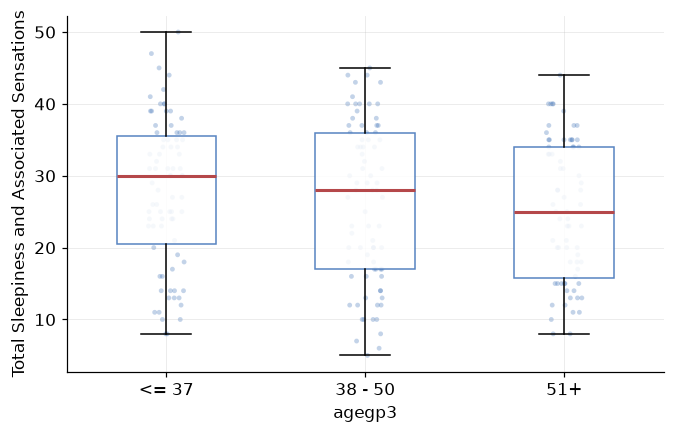

```python
m9.grouped_box(sleep, "totsas", "agegp3", ylabel="Total Sleepiness and Associated Sensations",
               order=sleep_ages);
```

```python
sleep_welch = stats.f_oneway(*sleep_groups, equal_var=False)
m9.report_anova(sleep, "totsas", "agegp3", sleep_welch,
                outcome_label="Total Sleepiness and Associated Sensations",
                order=sleep_ages)
```

Welch's one-way ANOVA was conducted to compare Total Sleepiness and Associated Sensations across 3 groups: <= 37 (*n* = 79, *M* = 27.77, *SD* = 10.30); 38 - 50 (*n* = 79, *M* = 26.08, *SD* = 11.18); 51+ (*n* = 72, *M* = 25.14, *SD* = 9.71). There was no statistically significant difference between the groups, *F*(2, 151.1) = 1.33, *p* = .268, η² = 0.011, ω² = 0.002 (negligible). This is not evidence that the group means are equal: the data do not provide sufficient evidence that they differ.

**No post-hoc comparisons.** The omnibus test found no evidence that any group differs, so there is nothing to locate. Running the pairs anyway, hoping one falls below .05, is exactly the multiple-comparison problem the omnibus test was there to prevent.

The effect size is still reported. A non-significant result with its effect size tells the reader how large a difference the data are consistent with; without it, they cannot tell "no difference" from "too few people to tell".

One more check worth making every time — the result object holds a *p*-value, and a *p*-value is a probability:

```python
print(f"F = {sleep_welch.statistic:.3f}, p = {sleep_welch.pvalue:.3f}")
assert 0 <= sleep_welch.pvalue <= 1
```

```
F = 1.330, p = 0.268
```

That looks too obvious to need saying. Reports with a *p* larger than one, and an *F* carrying three degrees of freedom, do get written and circulated; the lecture shows one. A value pasted into the wrong slot of a sentence template survives because a typed number looks exactly as authoritative as a correct one.

## Part 3 — An ordinal outcome: maths grades and social class

The Youth Cohort Study of England and Wales: thirteen thousand young people who reached school-leaving age in 2002, with their GCSE grades and their family's social class.

```python
youth = m9.load_youthcohort()
m9.frequency(youth, "gradmath")
```

| gradmath | count | percent | valid_percent |
| --- | --- | --- | --- |
| A | 1738 | 13.17 | 13.41 |
| A* | 717 | 5.43 | 5.53 |
| B | 2960 | 22.42 | 22.85 |
| C | 2820 | 21.36 | 21.77 |
| D | 1854 | 14.04 | 14.31 |
| E | 1530 | 11.59 | 11.81 |
| F | 811 | 6.14 | 6.26 |
| Fail | 236 | 1.79 | 1.82 |
| G | 290 | 2.20 | 2.24 |
| NaN | 245 | 1.86 | NaN |

A GCSE grade is **ordinal**: A* is above A, which is above B, but the gap between A* and A is not the same thing as the gap between F and G. A mean grade means nothing. This is a rank test.

### Recoding: write the order out, then check it

The grades are stored as text, and text sorts alphabetically — the table above puts `A` before `A*`, and `Fail` between `F` and `G`. Map them to codes in the order you mean:

```python
# An ordinal outcome stored as text. Write the order out in full,
# then check that the recode lost nothing it should not have.
grades = ["A*", "A", "B", "C", "D", "E", "F", "G", "Fail"]
youth["mathcode"] = youth.gradmath.map({g: i + 1 for i, g in enumerate(grades)})

lost = youth.gradmath.notna() & youth.mathcode.isna()
print(f"grades lost to the recode: {lost.sum()}")
```

```
grades lost to the recode: 0
```

**That last line is the point of this section.** Any value the mapping does not name becomes missing, silently. Here is what happens if the bottom grade is written the way GCSE results usually print it, as `U` for unclassified, when this dataset says `Fail`:

```python
wrong = youth.gradmath.map({g: i + 1 for i, g in enumerate(["A*", "A", "B", "C", "D", "E", "F", "G", "U"])})
dropped = youth.gradmath.notna() & wrong.isna()
print(f"grades lost to the wrong label: {dropped.sum()}")

# Of the students who have a grade, the share in each class that the wrong label loses
youth[youth.gradmath.notna()].assign(dropped=dropped).groupby("famsec").dropped.mean().sort_values()
```

```
grades lost to the wrong label: 236
```

```
famsec
Large employers and higher professionals               0.005848
Lower professional and higher technical occupations    0.009909
Intermediate occupations                               0.018068
Lower supervisory occupations                          0.021134
Other                                                  0.035424
Semi routine and routine occupations                   0.044554
Name: dropped, dtype: float64
```

Every failed grade disappears, and the loss is not even: the lower the social class, the larger the share of its students who vanish. An analysis run on that recode would understate the very gradient it was looking for — and nothing would warn you, because a missing value is not an error. Count before and after every recode.

### Steps 1–2: Hypothesis and inspection

> **H₀:** The distribution of maths grades is the same in every social class group.

> **H₁:** In at least one social class group, maths grades tend to be higher or lower than in the others.

H₁ is not a restatement of H₀ with the word "no" left in. Check yours: the two must be contradictory, so that exactly one of them is true.

```python
classes = [
    "Large employers and higher professionals",
    "Lower professional and higher technical occupations",
    "Intermediate occupations",
    "Lower supervisory occupations",
    "Semi routine and routine occupations",
    "Other",
]
graded = youth.dropna(subset=["mathcode"])
pd.crosstab(graded.famsec, graded.gradmath, normalize="index").reindex(
    index=classes, columns=grades).round(3)
```

| gradmath famsec | A* | A | B | C | D | E | F | G | Fail |
| --- | --- | --- | --- | --- | --- | --- | --- | --- | --- |
| Large employers and higher professionals | 0.116 | 0.232 | 0.283 | 0.187 | 0.089 | 0.063 | 0.017 | 0.007 | 0.006 |
| Lower professional and higher technical occupations | 0.068 | 0.155 | 0.263 | 0.230 | 0.132 | 0.093 | 0.038 | 0.010 | 0.010 |
| Intermediate occupations | 0.035 | 0.109 | 0.235 | 0.245 | 0.157 | 0.124 | 0.061 | 0.014 | 0.018 |
| Lower supervisory occupations | 0.009 | 0.059 | 0.158 | 0.237 | 0.193 | 0.168 | 0.110 | 0.046 | 0.021 |
| Semi routine and routine occupations | 0.013 | 0.052 | 0.144 | 0.199 | 0.204 | 0.186 | 0.115 | 0.044 | 0.045 |
| Other | 0.022 | 0.077 | 0.157 | 0.193 | 0.148 | 0.173 | 0.132 | 0.062 | 0.035 |

Read along the rows. Add the A* and A columns together and they shrink at every step down the class scale; add the columns below C and they grow at every step. `Other` is not a rung on the class scale — it is a separate group, and it is read as one.

### Step 3: Assumptions

Kruskal–Wallis assumes independent observations, an outcome that can at least be ranked, and — only if you want to talk about medians — groups whose distributions have the same shape. It does not assume normality.

The dataset also carries a survey weight, `s1weight`, which corrects for non-response (Unit 3). scipy's rank tests cannot apply it, so this analysis is **unweighted**: its results describe this sample, and generalising them to the whole cohort assumes the non-response did not distort the class gradient. That is a limitation you state, not one you hide.

### Step 4: Run the omnibus test

```python
# Kruskal-Wallis uses only the ranks, so the codes need only be in order.
# Here 1 is A* and 9 is Fail: a LOW rank is a GOOD grade.
kw = youth.dropna(subset=["mathcode"])
by_class = [kw.loc[kw.famsec == c, "mathcode"] for c in classes]
h = stats.kruskal(*by_class)

eta2_h = m9.eta_squared_h(h.statistic, len(by_class), len(kw))
print(f"H = {h.statistic:.1f}, p = {h.pvalue:.3g}, eta squared (H) = {eta2_h:.3f}")
```

```
H = 1646.0, p = 0, eta squared (H) = 0.127
```

scipy prints *p* as zero. It is not zero — it is smaller than the computer can represent — and it is reported as *p* < .001, never as *p* = 0. With thirteen thousand students it tells you nothing beyond "not chance": the **effect size** carries the finding. η²(*H*) is the rank-based share of variance, read against the same benchmarks as η².

### Step 4b: Dunn's test, with a stated correction

Six groups make fifteen pairs. Dunn's test compares every pair on the ranks the Kruskal–Wallis test already used, and the correction for multiple comparisons is yours to name:

```python
# Dunn's test on the same pooled ranks. The correction is not optional:
# fifteen pairs at .05 would turn up a false positive more often than not.
pairs = m9.dunn(kw, "mathcode", "famsec", p_adjust="holm", order=classes)
pairs[["A", "B", "z", "p_unadj", "p_adj"]]
```

|  | A | B | z | p_unadj | p_adj |
| --- | --- | --- | --- | --- | --- |
| 0 | Large employers and higher professionals | Lower professional and higher technical occupa... | -12.200473 | 3.090231e-34 | 2.163162e-33 |
| 1 | Large employers and higher professionals | Intermediate occupations | -20.894644 | 5.990152e-97 | 6.589167e-96 |
| 2 | Large employers and higher professionals | Lower supervisory occupations | -25.582602 | 2.382786e-144 | 3.097622e-143 |
| 3 | Large employers and higher professionals | Semi routine and routine occupations | -30.942400 | 3.215063e-210 | 4.822594e-209 |
| 4 | Large employers and higher professionals | Other | -28.235657 | 2.135316e-175 | 2.989443e-174 |
| 5 | Lower professional and higher technical occupa... | Intermediate occupations | -9.843765 | 7.292905e-23 | 2.917162e-22 |
| 6 | Lower professional and higher technical occupa... | Lower supervisory occupations | -17.605525 | 2.234282e-69 | 2.010854e-68 |
| 7 | Lower professional and higher technical occupa... | Semi routine and routine occupations | -22.329797 | 1.897880e-110 | 2.277456e-109 |
| 8 | Lower professional and higher technical occupa... | Other | -19.628709 | 8.792090e-86 | 8.792090e-85 |
| 9 | Intermediate occupations | Lower supervisory occupations | -10.332430 | 5.027056e-25 | 2.513528e-24 |
| 10 | Intermediate occupations | Semi routine and routine occupations | -14.026416 | 1.074461e-44 | 8.595686e-44 |
| 11 | Intermediate occupations | Other | -11.535273 | 8.760839e-31 | 5.256504e-30 |
| 12 | Lower supervisory occupations | Semi routine and routine occupations | -2.003528 | 4.512063e-02 | 1.353619e-01 |
| 13 | Lower supervisory occupations | Other | -0.154071 | 8.775537e-01 | 8.775537e-01 |
| 14 | Semi routine and routine occupations | Other | 1.985273 | 4.711412e-02 | 1.353619e-01 |

**Bonferroni** multiplies every *p* by the number of pairs. **Holm** does the same in steps — the smallest *p* by fifteen, the next by fourteen, and so on — and so it is never less powerful than Bonferroni while protecting against the same error. Either is defensible; leaving the correction out is not. Here the two agree, as they will when every *p* is either tiny or large:

```python
bonferroni = m9.dunn(kw, "mathcode", "famsec", p_adjust="bonferroni", order=classes)
print(f"significant after Holm:       {(pairs.p_adj < 0.05).sum()} of {len(pairs)}")
print(f"significant after Bonferroni: {(bonferroni.p_adj < 0.05).sum()} of {len(pairs)}")
```

```
significant after Holm:       12 of 15
significant after Bonferroni: 12 of 15
```

### Steps 5–6: Report and conclude

```python
m9.report_kruskal(
    kw, "mathcode", "famsec", h,
    outcome_label="GCSE mathematics grade",
    order=classes,
    value_labels={i + 1: g for i, g in enumerate(grades)},
)
```

A Kruskal-Wallis test was conducted to compare GCSE mathematics grade across 6 groups: Large employers and higher professionals (*n* = 2,736, *Mdn* = B, middle half from A to C); Lower professional and higher technical occupations (*n* = 3,532, *Mdn* = C, middle half from B to D); Intermediate occupations (*n* = 2,878, *Mdn* = C, middle half from B to D); Lower supervisory occupations (*n* = 1,041, *Mdn* = D, middle half from C to E); Semi routine and routine occupations (*n* = 1,414, *Mdn* = D, middle half from C to E); Other (*n* = 1,355, *Mdn* = D, middle half from B to E). There was a statistically significant difference between the groups, *H*(5) = 1645.98, *p* < .001, η²(*H*) = 0.127 (medium). The test compares whole distributions of ranks, so it supports a conclusion about which groups tend to score higher, not about the medians alone.

The medians are reported as grades, not codes, and where a quartile falls between two grades the sentence says so rather than rounding.

**Conclusion.** There is evidence to reject H₀: maths grades are not distributed alike across the social class groups, and the effect is of medium size. The pattern runs in one direction — students from higher-class families tend to have higher grades.

Note what this does *not* establish. It is an association in observational data; it does not show that social class *causes* the difference in grades, and it cannot separate class from everything that travels with it — school, region, household income.

## Choosing between the tests

```python
m9.md("""
| Your outcome | Your groups | Omnibus | Follow-up |
|---|---|---|---|
| Continuous, roughly normal within groups | 3 or more | Welch's ANOVA | Games–Howell |
| Ordinal, clearly skewed, or very small groups | 3 or more | Kruskal–Wallis | Dunn, with Holm or Bonferroni |
| Continuous or ordinal | 2 | Unit 4: Welch's *t* or Mann–Whitney | — |
""")
```

| Your outcome | Your groups | Omnibus | Follow-up |
| --- | --- | --- | --- |
| Continuous, roughly normal within groups | 3 or more | Welch's ANOVA | Games–Howell |
| Ordinal, clearly skewed, or very small groups | 3 or more | Kruskal–Wallis | Dunn, with Holm or Bonferroni |
| Continuous or ordinal | 2 | Unit 4: Welch's *t* or Mann–Whitney | — |

Three habits to carry forward:

- **Run the omnibus first, and follow up only what it found.** Hunting through the pairs after a non-significant omnibus is the problem ANOVA exists to prevent.
- **Name the correction.** A post-hoc *p*-value means nothing until the reader knows how it was adjusted.
- **Write the order of the groups out**, once, and check every recode by counting before and after.

## Exercise

`exercise.md` asks you to run both tests on questions you have not seen, including one where a group is too small to analyse — and to decide what to do about it.